# Week 3 - Homework

STAT 420, Summer 2018, apoorva6

## Exercise 1 (Using `lm` for Inference)

For this exercise we will use the `cats` dataset from the `MASS` package.

**(a)** Fit the following simple linear regression model in `R`. Use heart weight as the response and body weight as the predictor.

$$Y_i = \beta_0 + \beta_1 x_i + \epsilon_i$$

Store the results in a variable called `cat_model`. Use a $t$ test to test the significance of the regression. Report the following:

- The null and alternative hypotheses
- The value of the test statistic
- The p-value of the test
- A statistical decision at $\alpha = 0.05$
- A conclusion in the context of the problem

Null Hypothesis : $H_0: \beta_1 = 0$ Alternate Hypothesis: $H_1: \beta_1 \neq 0$

```r
cats <- MASS :: cats
cat_model <- lm(Hwt~Bwt, data=cats)

#ttest <-t.test(cats$Hwt,cats$Bwt)

test_statistic <- summary(cat_model)$coefficients[,3]
names(test_statistic) <- c("teststat_beta0","teststat_beta1")
test_statistic
```

```
## teststat_beta0 teststat_beta1
##     -0.5152019     16.1193908
```

```r
# The p-value of the test
p_value <- summary(cat_model)$coefficients[,4]
names(p_value) <- c("pvalue_beta0","pvalue_beta1")
p_value
```

```
## pvalue_beta0 pvalue_beta1
## 6.072131e-01 6.969045e-34
```

```r
# A statistical decision at α=0.05
p_value[2] < 0.05
```

```
## pvalue_beta1
##         TRUE
```

Since the P value for the above model is less than the significance level $\alpha$=0.05, we reject the NULL hypothesis. Thus the body weight and heart weight of cats are inter-related.

**(b)** Calculate a 90% confidence interval for $\beta_1$. Give an interpretation of the interval in the context of the problem.

```r
confint(cat_model, parm = "Bwt", level= 0.90)
```

```
##          5 %     95 %
## Bwt 3.619716 4.448409
```

**(c)** Calculate a 99% confidence interval for $\beta_0$. Give an interpretation of the interval in the context of the problem.

```r
confint(cat_model, parm = "(Intercept)", level= 0.99)
```

```
##                 0.5 % 99.5 %
## (Intercept) -2.164125 1.4508
```

This range captures 99% area where the true values of beta_0 lies.

**(d)** Use a 99% confidence interval to estimate the mean heart weight for body weights of 2.1 and 2.8 kilograms. Which of the two intervals is wider? Why?

```r
newdata1 <- data.frame(Bwt = c(2.1,2.8))
predict(cat_model, newdata= newdata1 , interval = c("confidence"),level = 0.99)
```

```
##         fit       lwr       upr
## 1  8.114869  7.599225  8.630513
## 2 10.938713 10.618796 11.258630
```

The confidence interval for the bodyweight = 2.1 is broader as compared to bodyweight=2.8 as the mean of bodyweights of the dataset is 2.72, and 2.8 is closer to the mean.

**(e)** Use a 99% prediction interval to predict the heart weight for body weights of 2.8 and 4.2 kilograms.

```r
newdata2 <- data.frame(Bwt = c(2.8,4.2))
predict(cat_model, newdata= newdata2 , interval = c("prediction"),level = 0.99)
```

```
##        fit       lwr      upr
## 1 10.93871  7.133247 14.74418
## 2 16.58640 12.660883 20.51192
```

**(f)** Create a scatterplot of the data. Add the regression line, 90% confidence bands, and 90% prediction bands.

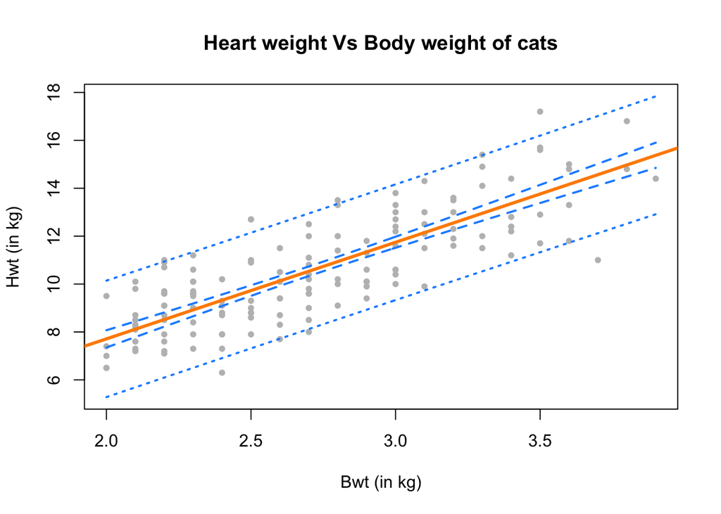

```r
weight_grid = seq(min(cats$Bwt), max(cats$Bwt), by = 0.01)
ci_band <- predict(cat_model, newdata= data.frame(Bwt = weight_grid) , interval = c("confidence"),level = 0.90)
pi_band <- predict(cat_model, newdata= data.frame(Bwt = weight_grid) , interval = c("prediction"),level = 0.90)

plot(Hwt ~ Bwt, data = cats,
     xlab = "Bwt (in kg)",
     ylab = "Hwt (in kg)",
     main = "Heart weight Vs Body weight of cats",
     pch  = 20,
     cex  = 1,
     col  = "grey",
     ylim = c(min(pi_band), max(pi_band)))
abline(cat_model, lwd = 3, col = "darkorange")

lines(weight_grid, ci_band[,"lwr"], col = "dodgerblue", lwd = 2, lty = 2)
lines(weight_grid, ci_band[,"upr"], col = "dodgerblue", lwd = 2, lty = 2)
lines(weight_grid, pi_band[,"lwr"], col = "dodgerblue", lwd = 2, lty = 3)
lines(weight_grid, pi_band[,"upr"], col = "dodgerblue", lwd = 2, lty = 3)
```

**(g)** Use a $t$ test to test:

- $H_0: \beta_1 = 4$
- $H_1: \beta_1 \neq 4$

Report the following:

- The value of the test statistic
- The p-value of the test
- A statistical decision at $\alpha = 0.05$

```r
ttest <-t.test(cats$Hwt,cats$Bwt,mu=4)
teststatistic <- ttest[1]
teststatistic
```

```
## $statistic
##        t
## 18.88528
```

```r
pvalue <- ttest[3]
pvalue
```

```
## $p.value
## [1] 5.75026e-42
```

```r
pvalue < 0.05
```

```
## p.value
##    TRUE
```

## Exercise 2 (More `lm` for Inference)

For this exercise we will use the `Ozone` dataset from the `mlbench` package.

```r
data(Ozone, package = "mlbench")
Ozone = Ozone[, c(4, 6, 7, 8)]
colnames(Ozone) = c("ozone", "wind", "humidity", "temp")
Ozone = Ozone[complete.cases(Ozone), ]
```

**(a)** Fit the following simple linear regression model in `R`. Use the ozone measurement as the response and wind speed as the predictor.

$$Y_i = \beta_0 + \beta_1 x_i + \epsilon_i$$

Store the results in a variable called `ozone_wind_model`. Use a $t$ test to test the significance of the regression. Report the following:

- The null and alternative hypotheses
- The value of the test statistic
- The p-value of the test
- A statistical decision at $\alpha = 0.01$
- A conclusion in the context of the problem

Null Hypothesis : $H_0: \beta_1 = 0$ Alternate Hypothesis: $H_1: \beta_1 \neq 0$

```r
ozone_wind_model <- lm(ozone~wind, data = Ozone)

test_statistic <- summary(ozone_wind_model)$coefficients[,3]
names(test_statistic) <- c("teststat_beta0","teststat_beta1")
test_statistic
```

```
## teststat_beta0 teststat_beta1
##     10.9278455     -0.2189811
```

```r
p_value <- summary(ozone_wind_model)$coefficients[,4]
names(p_value) <- c("pvalue_beta0","pvalue_beta1")
p_value
```

```
## pvalue_beta0 pvalue_beta1
## 4.818462e-24 8.267954e-01
```

```r
p_value[2] < 0.01
```

```
## pvalue_beta1
##        FALSE
```

**(b)** Fit the following simple linear regression model in `R`. Use the ozone measurement as the response and temperature as the predictor.

$$Y_i = \beta_0 + \beta_1 x_i + \epsilon_i$$

Store the results in a variable called `ozone_temp_model`. Use a $t$ test to test the significance of the regression. Report the following:

- The null and alternative hypotheses
- The value of the test statistic
- The p-value of the test
- A statistical decision at $\alpha = 0.01$
- A conclusion in the context of the problem

Null Hypothesis : $H_0: \beta_1 = 0$ Alternate Hypothesis: $H_1: \beta_1 \neq 0$

```r
ozone_temp_model. <- lm(ozone~temp, data = Ozone)

test_statistic <- summary(ozone_temp_model.)$coefficients[,3]
names(test_statistic) <- c("teststat_beta0","teststat_beta1")
test_statistic
```

```
## teststat_beta0 teststat_beta1
##      -12.48425       22.84896
```

```r
p_value <- summary(ozone_temp_model.)$coefficients[,4]
names(p_value) <- c("pvalue_beta0","pvalue_beta1")
p_value
```

```
## pvalue_beta0 pvalue_beta1
## 9.947455e-30 8.153764e-71
```

```r
p_value < 0.01
```

```
## pvalue_beta0 pvalue_beta1
##         TRUE         TRUE
```

Since the P value for the above model is less than the significance level $\alpha$=0.01, we reject the NULL hypothesis. Thus temperature plays an important role in obtaining accurate ozone readings.

## Exercise 3 (Simulating Sampling Distributions)

For this exercise we will simulate data from the following model:

$$Y_i = \beta_0 + \beta_1 x_i + \epsilon_i$$

Where $\epsilon_i \sim N(0, \sigma^2).$ Also, the parameters are known to be:

- $\beta_0 = -5$
- $\beta_1 = 3.25$
- $\sigma^2 = 16$

We will use samples of size $n = 50$.

**(a)** Simulate this model $2000$ times. Each time use `lm()` to fit a simple linear regression model, then store the value of $\hat{\beta}_0$ and $\hat{\beta}_1$.

```r
 beta_0 <- -5
  beta_1 <- 3.25
  sigma <- 4
  birthday = 19920720
  set.seed(birthday)
  n = 50
  x = seq(0, 10, length = n)
  Sxx = sum((x - mean(x)) ^ 2)
  var_beta_1_hat = sigma ^ 2 / Sxx
  var_beta_0_hat = sigma ^ 2 * (1 / n + mean(x) ^ 2 / Sxx)

  beta_0_hats <- as.vector(rep(0,2000))
  beta_1_hats <- as.vector(rep(0,2000))
  for (i in 1:2000)
  {

    epsilon = rnorm(n, mean = 0, sd = sigma)
    y = beta_0 + beta_1 * x + epsilon
    sim_model<-  lm(y ~ x)
    beta_0_hats[i] <- coef(sim_model)[1]
    beta_1_hats[i] <- coef(sim_model)[2]
    i <- i+1
  }
```

**(b)** Create a table that summarizes the results of the simulations. The table should have two columns, one for $\hat{\beta}_0$ and one for $\hat{\beta}_1$. The table should have four rows:

- A row for the true expected value given the known values of $x$
- A row for the mean of the simulated values
- A row for the true standard deviation given the known values of $x$
- A row for the standard deviation of the simulated values

```r
 true_expected <-c(beta_0,beta_1)
 simulated_mean <-  c(mean(beta_0_hats),mean(beta_1_hats))
 true_sd <-  sqrt(c(var_beta_0_hat,var_beta_1_hat))
 emp_sd <- sqrt(c(var(beta_0_hats),var(beta_1_hats)))

table <- as.data.frame(rbind(true_expected,simulated_mean,true_sd,emp_sd))
colnames(table) <- c(expression(betahat_0),expression(betahat_1))

library(knitr)
kable(table, format = "markdown")
```

|  | betahat_0 | betahat_1 |
| --- | --- | --- |
| true_expected | -5.000000 | 3.2500000 |
| simulated_mean | -5.041101 | 3.2552107 |
| true_sd | 1.114609 | 0.1920784 |
| emp_sd | 1.104075 | 0.1917585 |

**(c)** Plot two histograms side-by-side:

- A histogram of your simulated values for $\hat{\beta}_0$. Add the normal curve for the true sampling distribution of $\hat{\beta}_0$.
- A histogram of your simulated values for $\hat{\beta}_1$. Add the normal curve for the true sampling distribution of $\hat{\beta}_1$.

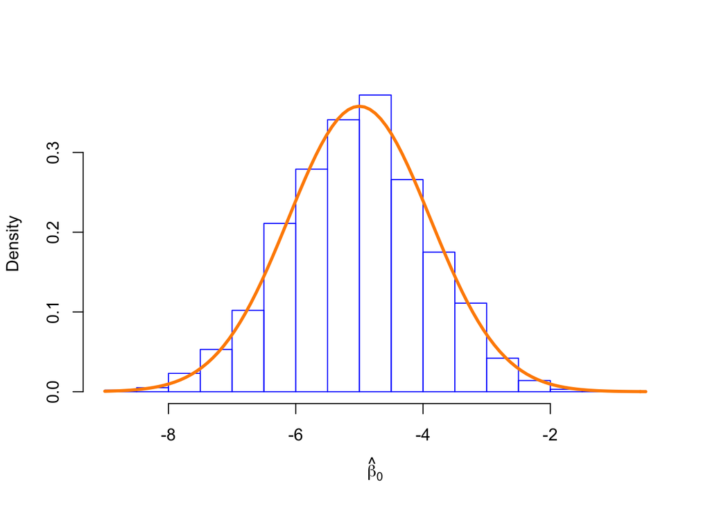

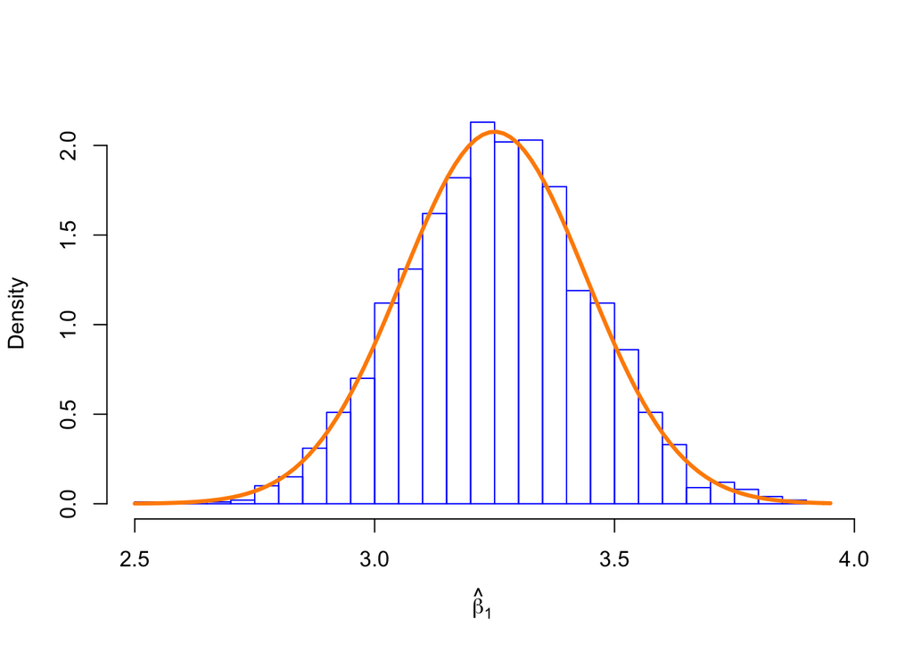

```r
  hist(beta_0_hats, prob = TRUE, breaks = 25,
       xlab = expression(hat(beta)[0]), main = "", border = "blue")
  curve(dnorm(x, mean = beta_0, sd = sqrt(var_beta_0_hat)),
        col = "darkorange", add = TRUE, lwd = 3)
  hist(beta_1_hats, prob = TRUE, breaks = 20,
       xlab = expression(hat(beta)[1]), main = "", border = "blue")
  curve(dnorm(x, mean = beta_1, sd = sqrt(var_beta_1_hat)),
        col = "darkorange", add = TRUE, lwd = 3)
```

## Exercise 4 (Simulating Confidence Intervals)

For this exercise we will simulate data from the following model:

$$Y_i = \beta_0 + \beta_1 x_i + \epsilon_i$$

Where $\epsilon_i \sim N(0, \sigma^2).$ Also, the parameters are known to be:

- $\beta_0 = 5$
- $\beta_1 = 2$
- $\sigma^2 = 9$

We will use samples of size $n = 25$.

Our goal here is to use simulation to verify that the confidence intervals really do have their stated confidence level.

**(a)** Simulate this model $2500$ times. Each time use `lm()` to fit a simple linear regression model, then store the value of $\hat{\beta}_1$ and $s_e$.

```r
 beta_0 <- 5
  beta_1 <- 2
  sigma <- 3
  birthday = 19920720
  set.seed(birthday)
  n = 25
  x = seq(0, 2.5, length = n)
  Sxx = sum((x - mean(x)) ^ 2)


  beta_hat_1_se <- as.vector(rep(0,2500))
  beta_1_hats <- as.vector(rep(0,2500))
  for (i in 1:2500)
  {
    epsilon = rnorm(n, mean = 0, sd = sigma)
    y = beta_0 + beta_1 * x + epsilon
    sim_model<-  lm(y ~ x)
    beta_1_hats[i] <- coef(sim_model)[2]
    beta_hat_1_se[i] <- summary(sim_model)$coefficient[2,2]
    i <- i+1
  }
```

**(b)** For each of the $\hat{\beta}_1$ that you simulated, calculate a 95% confidence interval. Store the lower limits in a vector `lower_95` and the upper limits in a vector `upper_95`.

```r
 1-((1-.95)/2)
```

```
## [1] 0.975
```

```r
  crit <- qt(0.975,df = n-2)
  lower_95 <- beta_1_hats - (crit*beta_hat_1_se)
  upper_95 <- beta_1_hats + (crit*beta_hat_1_se)
```

**(c)** What proportion of these intervals contains the true value of $\beta_1$?

```r
 true_int <- table(beta_1 >= lower_95 & beta_1 <= upper_95)
    as.vector(true_int[2]/length(upper_95))
```

```
## [1] 0.952
```

**(d)** Based on these intervals, what proportion of the simulations would reject the test $H_0: \beta_1 = 0$ vs $H_1: \beta_1 \neq 0$ at $\alpha = 0.05$?

```r
contains_null <- table(0 >= lower_95 & 0 <= upper_95)
    as.vector(contains_null[1]/length(lower_95))
```

```
## [1] 0.6672
```

**(e)** For each of the $\hat{\beta}_1$ that you simulated, calculate a 99% confidence interval. Store the lower limits in a vector `lower_99` and the upper limits in a vector `upper_99`.

```r
crit_99 <- qt(0.995 ,df = n-2)
  lower_99 <- beta_1_hats - (crit_99*beta_hat_1_se)
  upper_99 <- beta_1_hats + (crit_99*beta_hat_1_se)
```

**(f)** What proportion of these intervals contains the true value of $\beta_1$?

```r
 true_int1 <- table(beta_1 >= lower_99 & beta_1 <= upper_99)
  as.vector(true_int1[2]/length(upper_99))
```

```
## [1] 0.9908
```

**(g)** Based on these intervals, what proportion of the simulations would reject the test $H_0: \beta_1 = 0$ vs $H_1: \beta_1 \neq 0$ at $\alpha = 0.01$?

```r
  contains_null1 <- table(0 >= lower_99 & 0 <= upper_99)
  as.vector(contains_null1[1]/length(lower_99))
```

```
## [1] 0.4108
```

## Exercise 5 (Prediction Intervals “without” `predict`)

Write a function named `calc_pred_int` that performs calculates prediction intervals:

$$\hat{y}(x) \pm t_{\alpha/2, n - 2} \cdot s_e\sqrt{1 + \frac{1}{n}+\frac{(x-\bar{x})^2}{S_{xx}}}.$$

for the linear model

$$Y_i = \beta_0 + \beta_1 x_i + \epsilon_i.$$

**(a)** Write this function.

The function should take three inputs:

- `model`, a model object that is the result of fitting the SLR model with `lm()`
- `newdata`, a data frame with a single observation (row)
  - This data frame will need to have a variable (column) with the same name as the data used to fit `model`.
- `level`, the level (0.90, 0.95, etc) for the interval with a default value of `0.95`

The function should return a named vector with three elements:

- `estimate`, the midpoint of the interval
- `lower`, the lower bound of the interval
- `upper`, the upper bound of the interval

```r
cats <- MASS::cats
cat_model <- lm(Hwt~Bwt, data=cats)

calc_pred_int <- function(model, newdata,level=0.95)
{

  #yhat
  n <- length(cat_model$fitted.values)
  y_hat <- predict(model,newdata = newdata)


  #crit value
  int  <- (1-  (1-level)/2)
  crit <-  qt(int, df = n -2)

  #SE
  x <- (model$fitted.values - model$coefficients[1])/ model$coefficients[2]
  s_e <- summary(model)$sigma
  Sxx = sum((x - mean(x)) ^ 2)
  SE = s_e*(sqrt(1+(1/n)+(as.vector(newdata) -mean(x)) ^2/Sxx))
  lower_bound <- y_hat - (crit*SE)
  upper_bound <- y_hat + (crit*SE)


    pred_int <- c(y_hat,lower_bound,upper_bound)
    pred_int_name <- unlist(pred_int, use.names=FALSE)
    names(pred_int_name) <- c("estimate","lower bound","upper bound")
    pred_int_name
}

  newcat_1 = data.frame(Bwt = 4.0)
  calc_pred_int(cat_model, newcat_1)
```

```
##    estimate lower bound upper bound
##    15.77959    12.83018    18.72900
```

```r
  newcat_2 = data.frame(Bwt = 3.3)
  calc_pred_int(cat_model, newcat_2, level = 0.99)
```

```
##    estimate lower bound upper bound
##   12.955744    9.132013   16.779476
```